# ACST3006 Assignment

### Question 2

We are given the monthly return for stocks, U.S. portfolios and country portfolios.

#### Part I

Let us calculate the mean return, standard deviation, correlations and variances/covariances on all available stocks / portfolios

```r
stock_returns <- fread("Data/Q2.csv")

# Manipulate Data ---------------------------------------------------------
# Store the investment categories and investment types
investment_categories <- as.character(unlist(stock_returns[1, ]))[-1]
investment_types <- as.character(unlist(stock_returns[2, ]))[-1]
stock_returns <- stock_returns[-c(1, 2)]
colnames(stock_returns) <- c("Date", as.vector(investment_types))

# Convert the data.table to long format using melt()
stock_returns_melt <- melt(stock_returns, id.vars = "Date", variable.name = "Investment", value.name = "Return")
stock_returns_melt[, Investment_Category := investment_categories[Investment], by = Investment]
stock_returns_melt <- stock_returns_melt[, .(Investment, Investment_Category, Date, Return)][, Return := as.numeric(Return)]

# Part I ------------------------------------------------------------------
# Calculate mean return
mean_returns <- stock_returns_melt[, .(Mean_Return = mean(Return)), by = .(Investment, Investment_Category)]
sd_returns <- stock_returns_melt[, .(SD_Return = sd(Return)), by = .(Investment, Investment_Category)]
risk_free_rate <- mean_returns[Investment == "US Riskfree", Mean_Return]

# Calculate the covariances and correlations among risky assets
risky_assets <- stock_returns_melt[Investment != "US Riskfree"]
risky_assets_wide <- dcast(risky_assets, Date ~ Investment, value.var = "Return")

# Remove the 'Date' column
risky_assets_wide[, Date:=NULL]

# Compute the covariance matrix
cov_matrix <- cov(risky_assets_wide)

# Compute the correlation matrix
cor_matrix <- cor(risky_assets_wide)

print(mean_returns)
```

```
##        Investment Investment_Category Mean_Return
##  1:       Barrick               Stock 0.006982614
##  2:        Hanson               Stock 0.011694433
##  3:           IBM               Stock 0.012608753
##  4:         Nokia               Stock 0.024412899
##  5:     Telefonos               Stock 0.020770891
##  6:           YPF               Stock 0.015601786
##  7:  Small-Growth        US Portfolio 0.007060833
##  8: Small-Neutral        US Portfolio 0.013927500
##  9:   Small-Value        US Portfolio 0.015358333
## 10:    Big-Growth        US Portfolio 0.007248333
## 11:   Big-Neutral        US Portfolio 0.010052500
## 12:     Big-Value        US Portfolio 0.009866667
## 13:     Australia        Country Port 0.011499167
## 14:     Hong Kong        Country Port 0.007920833
## 15:         Italy        Country Port 0.013620000
## 16:         Japan        Country Port 0.004193333
## 17:        Norway        Country Port 0.013995000
## 18:            US        Country Port 0.008180833
## 19:   US Riskfree         US Riskfree 0.002955000
```

```r
print(sd_returns)
```

```
##        Investment Investment_Category   SD_Return
##  1:       Barrick               Stock 0.103131449
##  2:        Hanson               Stock 0.100000464
##  3:           IBM               Stock 0.093900305
##  4:         Nokia               Stock 0.137372385
##  5:     Telefonos               Stock 0.090853756
##  6:           YPF               Stock 0.103367615
##  7:  Small-Growth        US Portfolio 0.080325100
##  8: Small-Neutral        US Portfolio 0.052199839
##  9:   Small-Value        US Portfolio 0.050267604
## 10:    Big-Growth        US Portfolio 0.048272493
## 11:   Big-Neutral        US Portfolio 0.043648941
## 12:     Big-Value        US Portfolio 0.043913437
## 13:     Australia        Country Port 0.050042626
## 14:     Hong Kong        Country Port 0.078340471
## 15:         Italy        Country Port 0.063317699
## 16:         Japan        Country Port 0.059087913
## 17:        Norway        Country Port 0.067774041
## 18:            US        Country Port 0.046010672
## 19:   US Riskfree         US Riskfree 0.001460451
```

```r
print(risk_free_rate)
```

```
## [1] 0.002955
```

```r
print(cov_matrix)
```

```
##                     Barrick        Hanson           IBM         Nokia
## Barrick        0.0106360959  0.0027643188  0.0007512164  0.0016980916
## Hanson         0.0027643188  0.0100000929  0.0018747776  0.0027808038
## IBM            0.0007512164  0.0018747776  0.0088172673  0.0053882443
## Nokia          0.0016980916  0.0027808038  0.0053882443  0.0188711721
## Telefonos      0.0022133436  0.0017497179  0.0032844480  0.0046522898
## YPF            0.0030350160  0.0023641431  0.0030329717  0.0028931109
## Small-Growth  -0.0014364252 -0.0008532713 -0.0001221233 -0.0009775305
## Small-Neutral -0.0008711034 -0.0004129873 -0.0001663115 -0.0011662960
## Small-Value   -0.0006889375 -0.0004128554 -0.0003739916 -0.0015805277
## Big-Growth    -0.0005171672 -0.0003804641 -0.0003032094 -0.0006168732
## Big-Neutral   -0.0004308487 -0.0003174727 -0.0002804707 -0.0011781403
## Big-Value     -0.0001621777 -0.0002098178 -0.0004928579 -0.0007941760
## Australia     -0.0008888694  0.0002600337 -0.0003801092 -0.0010324777
## Hong Kong      0.0002885422  0.0004268208  0.0004642905 -0.0014112806
## Italy         -0.0001913227 -0.0005287051 -0.0006753240 -0.0007214031
## Japan         -0.0011172429  0.0006839182 -0.0004214222 -0.0002983091
## Norway        -0.0010389594 -0.0007582393 -0.0008472796 -0.0024846463
## US            -0.0006372899 -0.0004225050 -0.0002689375 -0.0008525204
##                   Telefonos           YPF  Small-Growth Small-Neutral
## Barrick        2.213344e-03  3.035016e-03 -1.436425e-03 -0.0008711034
## Hanson         1.749718e-03  2.364143e-03 -8.532713e-04 -0.0004129873
## IBM            3.284448e-03  3.032972e-03 -1.221233e-04 -0.0001663115
## Nokia          4.652290e-03  2.893111e-03 -9.775305e-04 -0.0011662960
## Telefonos      8.254405e-03  3.632472e-03 -7.452495e-06 -0.0003195443
## YPF            3.632472e-03  1.068486e-02  6.126751e-05 -0.0004078800
## Small-Growth  -7.452495e-06  6.126751e-05  6.452122e-03  0.0038269745
## Small-Neutral -3.195443e-04 -4.078800e-04  3.826975e-03  0.0027248232
## Small-Value   -5.445284e-04 -6.669954e-04  3.393355e-03  0.0025302356
## Big-Growth    -3.186231e-04  4.721554e-04  2.803494e-03  0.0016614861
## Big-Neutral   -5.175653e-04 -1.296924e-04  1.839819e-03  0.0015593235
## Big-Value     -4.168299e-04 -7.557581e-05  1.459081e-03  0.0013465364
## Australia     -6.688977e-04  1.093825e-04  2.440202e-03  0.0016072925
## Hong Kong     -1.725347e-04  4.694475e-04  3.220957e-03  0.0023338759
## Italy         -1.064647e-03  1.738681e-04  3.059136e-03  0.0018669556
## Japan         -6.677112e-04  1.168262e-04  1.891170e-03  0.0010566868
## Norway        -1.427836e-03 -6.278791e-04  3.151152e-03  0.0023080069
## US            -3.469129e-04  2.503504e-04  2.996994e-03  0.0018872436
##                 Small-Value    Big-Growth   Big-Neutral     Big-Value
## Barrick       -0.0006889375 -0.0005171672 -0.0004308487 -1.621777e-04
```

[output cut: 40 more lines]

```
## Nokia         -0.0024846463 -0.0008525204
## Telefonos     -0.0014278359 -0.0003469129
## YPF           -0.0006278791  0.0002503504
## Small-Growth   0.0031511524  0.0029969937
## Small-Neutral  0.0023080069  0.0018872436
## Small-Value    0.0022230330  0.0017309357
## Big-Growth     0.0016495291  0.0021549775
## Big-Neutral    0.0018056856  0.0016565761
## Big-Value      0.0015100656  0.0014677746
## Australia      0.0022106706  0.0015686001
## Hong Kong      0.0025858945  0.0021564129
## Italy          0.0023767914  0.0017932840
## Japan          0.0016375593  0.0012820670
## Norway         0.0045933206  0.0019555389
## US             0.0019555389  0.0021169819
```

```r
print(cor_matrix)
```

```
##                   Barrick      Hanson         IBM       Nokia    Telefonos
## Barrick        1.00000000  0.26803715  0.07757235  0.11985898  0.236219004
## Hanson         0.26803715  1.00000000  0.19965525  0.20242722  0.192585296
## IBM            0.07757235  0.19965525  1.00000000  0.41771574  0.384992706
## Nokia          0.11985898  0.20242722  0.41771574  1.00000000  0.372755820
## Telefonos      0.23621900  0.19258530  0.38499271  0.37275582  1.000000000
## YPF            0.28469862  0.22871110  0.31247614  0.20374227  0.386789691
## Small-Growth  -0.17339661 -0.10622673 -0.01619125 -0.08858896 -0.001021192
## Small-Neutral -0.16181152 -0.07911622 -0.03393017 -0.16264480 -0.067378152
## Small-Value   -0.13289252 -0.08213112 -0.07923311 -0.22888350 -0.119231070
## Big-Growth    -0.10388195 -0.07881555 -0.06689226 -0.09302437 -0.072649831
## Big-Neutral   -0.09571058 -0.07273287 -0.06843003 -0.19648249 -0.130511442
## Big-Value     -0.03580985 -0.04777965 -0.11952460 -0.13164971 -0.104476479
## Australia     -0.17222918  0.05196221 -0.08089120 -0.15019005 -0.147121692
## Hong Kong      0.03571346  0.05448255  0.06311558 -0.13113776 -0.024240822
## Italy         -0.02929883 -0.08349997 -0.11358476 -0.08293798 -0.185070752
## Japan         -0.18334025  0.11574534 -0.07595419 -0.03675094 -0.124379027
## Norway        -0.14864286 -0.11187702 -0.13313626 -0.26687123 -0.231884658
## US            -0.13430349 -0.09182719 -0.06224805 -0.13487976 -0.082988697
##                        YPF Small-Growth Small-Neutral Small-Value  Big-Growth
## Barrick        0.284698622 -0.173396613   -0.16181152 -0.13289252 -0.10388195
## Hanson         0.228711101 -0.106226734   -0.07911622 -0.08213112 -0.07881555
## IBM            0.312476143 -0.016191251   -0.03393017 -0.07923311 -0.06689226
## Nokia          0.203742272 -0.088588956   -0.16264480 -0.22888350 -0.09302437
## Telefonos      0.386789691 -0.001021192   -0.06737815 -0.11923107 -0.07264983
## YPF            1.000000000  0.007378948   -0.07559251 -0.12836605  0.09462388
## Small-Growth   0.007378948  1.000000000    0.91271488  0.84040737  0.72301711
## Small-Neutral -0.075592510  0.912714884    1.00000000  0.96428101  0.65936791
## Small-Value   -0.128366051  0.840407373    0.96428101  1.00000000  0.61629275
## Big-Growth     0.094623882  0.723017107    0.65936791  0.61629275  1.00000000
## Big-Neutral   -0.028744602  0.524747092    0.68437376  0.69969236  0.75852797
## Big-Value     -0.016649489  0.413647739    0.58742375  0.62618902  0.66775945
## Australia      0.021145758  0.607063855    0.61529824  0.59693700  0.61401847
## Hong Kong      0.057971748  0.511855689    0.57071911  0.52772094  0.52293920
## Italy          0.026565027  0.601481619    0.56485854  0.54072771  0.55432031
## Japan          0.019127449  0.398456194    0.34259299  0.33048302  0.45026599
## Norway        -0.089624793  0.578834956    0.65238590  0.65252077  0.50419306
## US             0.052638710  0.810916208    0.78577863  0.74840071  0.97025175
##               Big-Neutral   Big-Value   Australia   Hong Kong       Italy
## Barrick       -0.09571058 -0.03580985 -0.17222918  0.03571346 -0.02929883
```

[output cut: 21 more lines]

```
## Nokia         -0.03675094 -0.26687123 -0.13487976
## Telefonos     -0.12437903 -0.23188466 -0.08298870
## YPF            0.01912745 -0.08962479  0.05263871
## Small-Growth   0.39845619  0.57883496  0.81091621
## Small-Neutral  0.34259299  0.65238590  0.78577863
## Small-Value    0.33048302  0.65252077  0.74840071
## Big-Growth     0.45026599  0.50419306  0.97025175
## Big-Neutral    0.32940351  0.61038665  0.82485781
## Big-Value      0.25489346  0.50738195  0.72644607
## Australia      0.57003731  0.65180931  0.68126105
## Hong Kong      0.46538529  0.48703620  0.59825616
## Italy          0.22770393  0.55386325  0.61555289
## Japan          1.00000000  0.40891685  0.47157796
## Norway         0.40891685  1.00000000  0.62711112
## US             0.47157796  0.62711112  1.00000000
```

#### Part II

To find the equation of the efficient frontier, we must:

1. Filter the data set for country portfolios
2. Calculate mean returns and covariance matrix
3. Apply the formulas for A, B, C and D as above
4. Apply the formula for the efficient frontier:

We can do this in R with the following code:

```r
# Filter the data to keep only the country portfolios
country_portfolios <- risky_assets[Investment_Category == "Country Port"]

# Calculate the mean returns and covariance matrix for the country portfolios
mean_returns <- country_portfolios[, .(Mean_Return = mean(Return)), by = Investment]
cov_matrix <- cov(country_portfolios[, dcast(.SD, Date ~ Investment, value.var = "Return")][, Date:=NULL])

A <- t(mean_returns$Mean_Return) %*% solve(cov_matrix) %*% mean_returns$Mean_Return
B <- t(rep(1, 6)) %*% solve(cov_matrix) %*% mean_returns$Mean_Return
C <- t(rep(1, 6)) %*% solve(cov_matrix) %*% rep(1,6)
D <- A * C - B^2

# Define the function for the portfolio variance
portfolio_variance <- function(E_Rp) {
  return((C * E_Rp^2 - 2 * B * E_Rp + A) / D)
}

# Define the range of expected returns
E_Rp_range <- seq(min(mean_returns$Mean_Return), max(mean_returns$Mean_Return), length.out = 500)

# Calculate the portfolio variances
portfolio_variances <- sapply(E_Rp_range, portfolio_variance)

# Calculate the portfolio standard deviations (Sigmas)
portfolio_sigmas <- sqrt(portfolio_variances)

# Create a data frame with the expected returns and portfolio standard deviations
efficient_frontier_data <- data.frame(E_Rp = E_Rp_range, Sigma = portfolio_sigmas)
```

We can also find the Global Minimum Variance Portfolio, by applying the following R code:

```r
GMVP_Return <- B/C
GMVP_Var <- 1/C
GMVP_SD <- 1/sqrt(C)
```

```
## The Global Minimum Variance Portfolio Return is:  0.008442998
```

[output not shown]

[output not shown]

This information can be displayed in a graph as below:

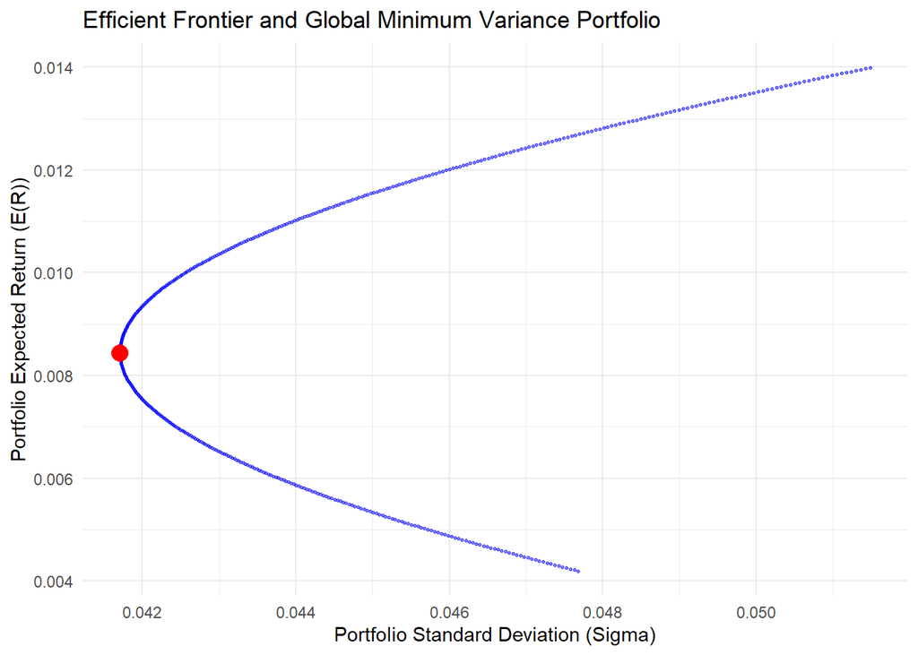

### Part 3

We now consider an investor considering all country portfolio’s, as well as the US risk-free portfolio.

We can calculate the equation for the CML by using the formula for optimal return and capital allocation line as above:

```r
optimal_return <- (A-risk_free_rate*B)/(B-risk_free_rate*C)
optimal_sd <- ((C*optimal_return^2-2*B*optimal_return+A)/D)^0.5

cml_slope <- (D*optimal_sd)/(C*optimal_return-B)
cml_intercept <- risk_free_rate
```

This gives us the following formula:
$$\begin{align}
E(R_p) &= 0.002955 + 0.2261123\times\sigma_{R_{p}}
\end{align}$$

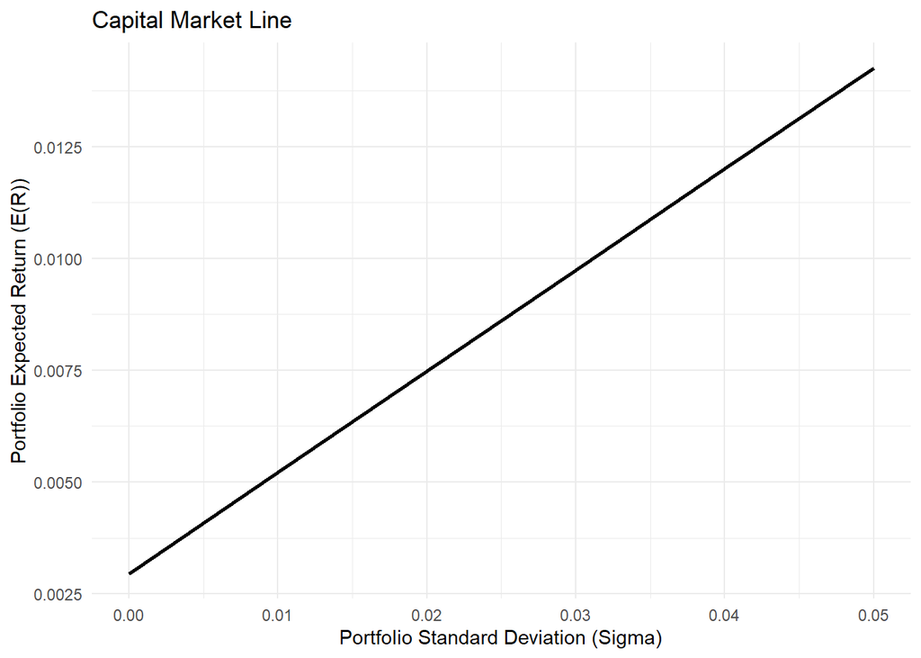

##### Optimal Weights

We can find the optimal weights of this portfolio with the formula as follows:

$$\begin{align}
W^* = \begin{bmatrix}
w_1^* \\
w_2^*
\end{bmatrix} &= V^{-1}
\begin{bmatrix}
E(\mathbf{R}), \mathbf{1} \end{bmatrix}\begin{bmatrix}
C & -B \\
-B & A
\end{bmatrix}\begin{bmatrix}
E(R_p*) \\
1
\end{bmatrix}\frac{1}{D}\\
\end{align}$$

In R:

```r
optimal_weights <- (solve(cov_matrix) %*%
                      matrix(c(mean_returns$Mean_Return, rep(1,nrow(mean_returns))), nrow=nrow(mean_returns)) %*%
                      matrix(c(C, -B, -B, A), nrow=2) %*%
                      matrix(c(optimal_return, 1), nrow = 2))/rep(D, 6)
```

```
##                 [,1]
## Australia  1.1945801
## Hong Kong -0.1737637
## Italy      0.5137039
## Japan     -0.5113280
## Norway     0.3675020
## US        -0.3906943
```

##### Portfolio Options

We can calculate the composition of various portfolios

```r
portfolio_options <- data.table(`Risky Portfolio` = c(0, 300000, 500000), `Risk Free Portfolio` = c(500000, 200000, 0))

portfolio_options[, `:=`(Return = `Risky Portfolio`*(1+optimal_return[1])+`Risk Free Portfolio`*(1+risk_free_rate),
             SD = sqrt(`Risky Portfolio`^2*optimal_sd[1]^2))]
```

Risky Portfolio

Risk Free Portfolio

Return

SD

$0

$500,000

$501,478

$0.00

$300,000

$200,000

$506,339

$21,500.10

$500,000

$0

$509,580

$$\beta_{iM}=\frac{E(R_i)-E(R_f)}{E(R_M)-E(R_f)},$$

for each portfolio $i$

```r
mean_returns[, Beta:=(Mean_Return-risk_free_rate)/(optimal_return[1] - risk_free_rate)]

# Find sml line
sml_slope <- optimal_return - risk_free_rate
sml_intercept <- risk_free_rate
print(mean_returns)
```

```
##    Investment Mean_Return       Beta
## 1:  Australia 0.011499167 0.52726191
## 2:  Hong Kong 0.007920833 0.30644238
## 3:      Italy 0.013620000 0.65813888
## 4:      Japan 0.004193333 0.07641775
## 5:     Norway 0.013995000 0.68128019
## 6:         US 0.008180833 0.32248702
```

We can plot this as:

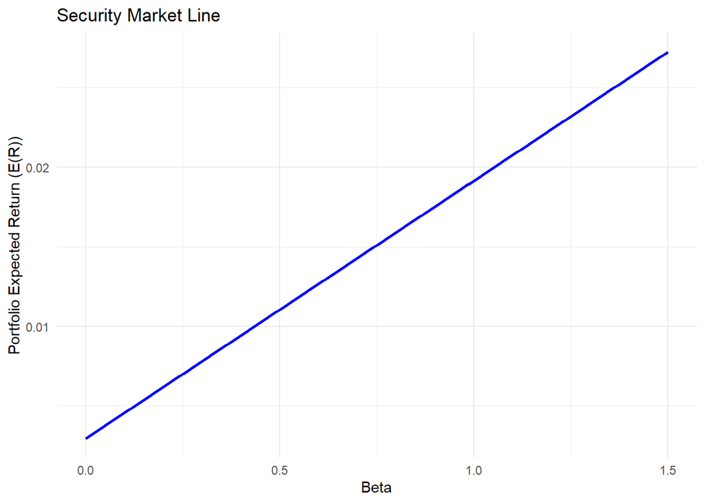

##### Interpretting Beta Values

The numerical beta values measure the systematic risk of an asset that cannot be diversified away. It is a measure of how the security / stock is correlated with the Market. For example, Australia’s $\beta_{iM} = 0.52726$. This means that when the market index (in this case the portfolio of countries) increases by 10%, the Australian portfolio will increase by 5.2726% and vice versa.

##### Example Portfolio

If we now consider a portfolio with a covariance of 0.0045 with the market, we get the following return:

```r
return = risk_free_rate + (0.0045/optimal_sd^2)*(optimal_return - risk_free_rate)
```

```
## The return of this portfolio is:  0.01715268
```